# House selling Prices

# Visualizing the Model - YearBuilt

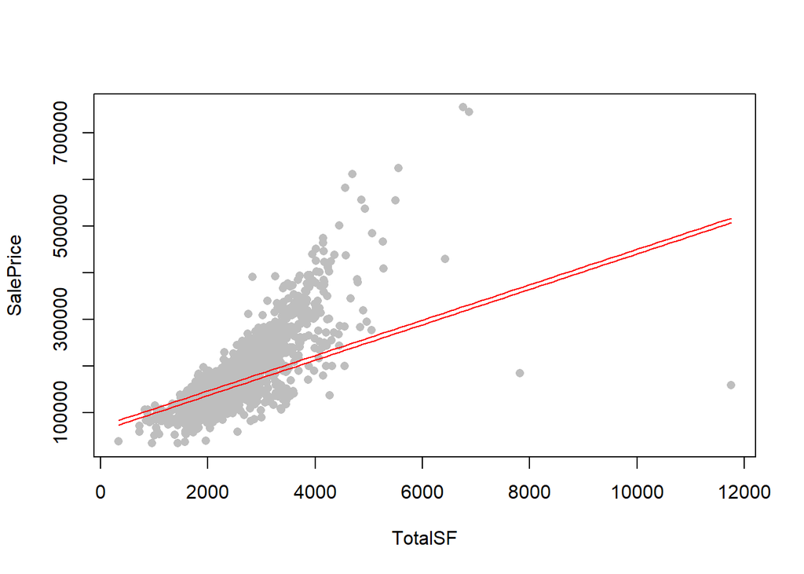

```r
model <- lm(SalePrice ~ GarageArea + YearBuilt + LotArea + YearRemodAdd + OverallQual + TotalSF, data = train)

b <- coef(model)

drawit1 <- function(col = "blue", GarageArea = 500, YearBuilt = 2000, LotArea = 1000, YearRemodAdd = 2005, OverallQual = 5, TotalSF = 15000) {
  curve(
    b[1] + b[2]*GarageArea + b[3]*YearBuilt + b[4]*LotArea + b[5]*YearRemodAdd + b[6]*OverallQual + b[7]*TotalSF,
    from = min(train$TotalSF, na.rm = TRUE),
    to = max(train$TotalSF, na.rm = TRUE),
    add = TRUE,
    col = col,
    xname = "TotalSF"
  )
}

options(scipen = 999)
plot(SalePrice ~ TotalSF, data = train, pch = 16, col = "grey")

drawit1(col = "red", GarageArea = 500, YearBuilt = 2025, LotArea = 1000, YearRemodAdd = 2005, OverallQual = 5, TotalSF = 15000)

drawit1(col = "red", GarageArea = 500, YearBuilt = 1970, LotArea = 1000, YearRemodAdd = 2005, OverallQual = 5, TotalSF = 15000)
```

Holding all other variables constant, when we look to see what year does to the model, there is no meaningful change.

# Visualizing the Model - GarageArea

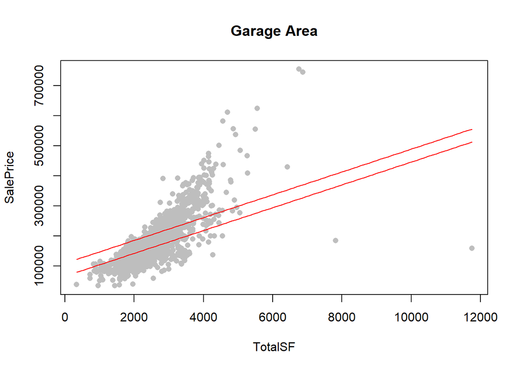

```r
options(scipen = 999)
plot(SalePrice ~ TotalSF, data = train, pch = 16, col = "grey", main = "Garage Area")

drawit1(col = "red", GarageArea = 1500, YearBuilt = 2000, LotArea = 1000, YearRemodAdd = 2005, OverallQual = 5, TotalSF = 15000)

drawit1(col = "red", GarageArea = 500, YearBuilt = 2000, LotArea = 1000, YearRemodAdd = 2005, OverallQual = 5, TotalSF = 15000)
```

With Garage Area, there is more of a change than the YearBuilt, but stil not overwhelmingly meaningful.

# Visualizing the Model - LotArea

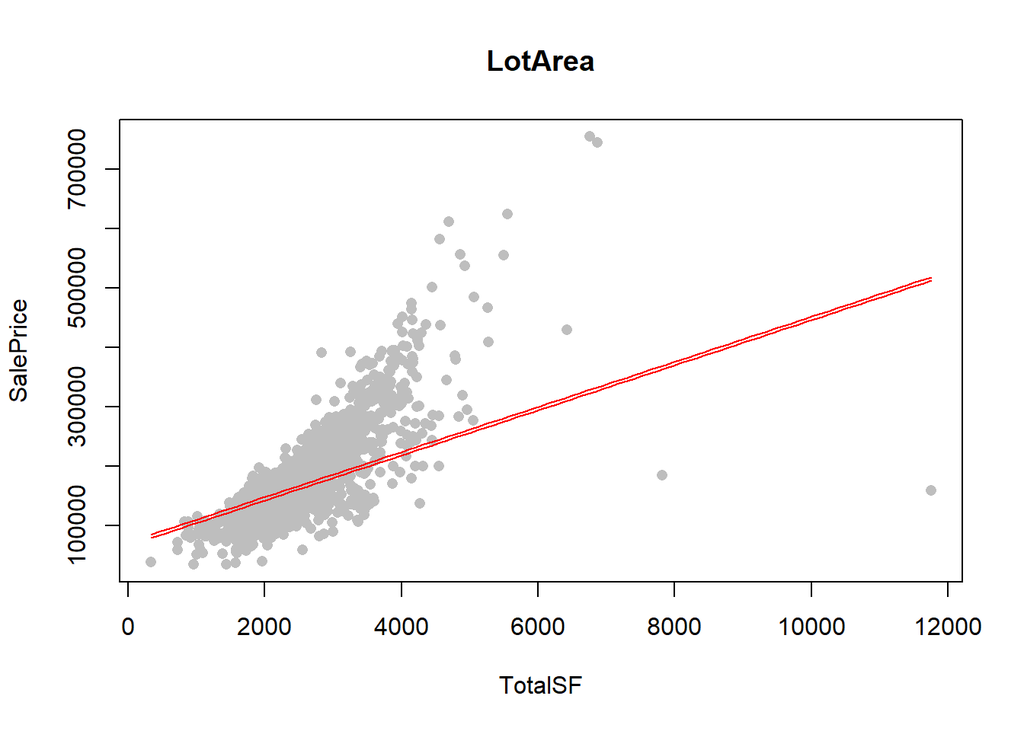

```r
options(scipen = 999)
plot(SalePrice ~ TotalSF, data = train, pch = 16, col = "grey", main = "LotArea")

drawit1(col = "red", GarageArea = 500, YearBuilt = 2000, LotArea = 1000, YearRemodAdd = 2005, OverallQual = 5, TotalSF = 15000)

drawit1(col = "red", GarageArea = 500, YearBuilt = 2000, LotArea = 10000, YearRemodAdd = 2005, OverallQual = 5, TotalSF = 15000)
```

Even with a Lot Area ten times as big, the change in value doesn’t go up significantly.

# Visualizing the Model - YearRemodAdd

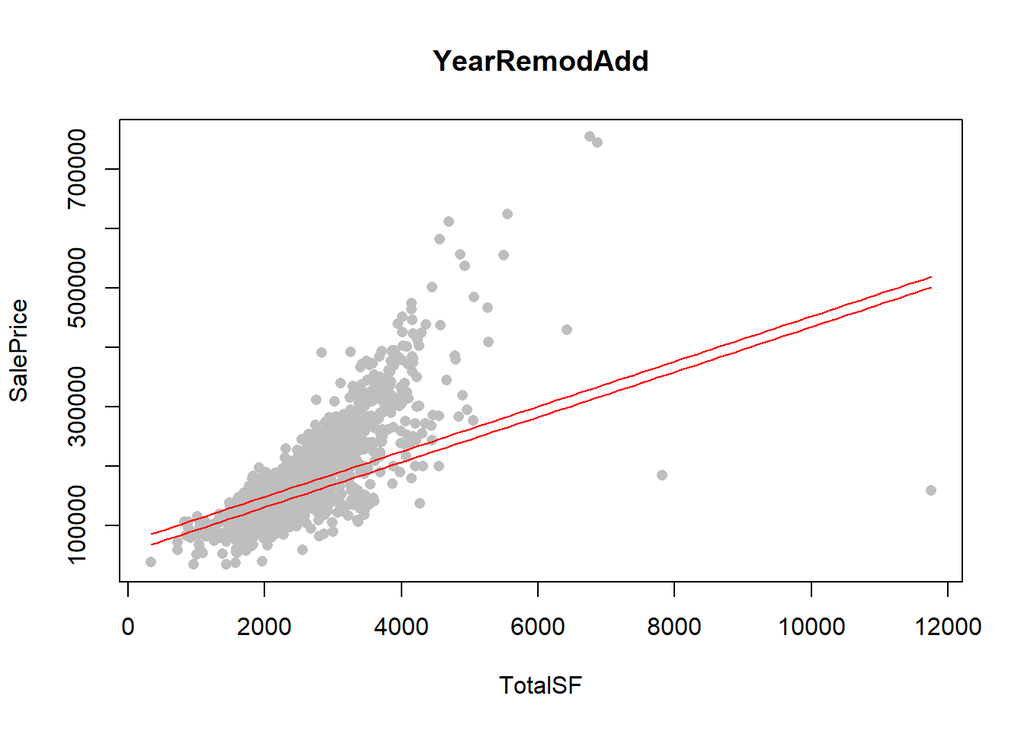

```r
options(scipen = 999)
plot(SalePrice ~ TotalSF, data = train, pch = 16, col = "grey", main = "YearRemodAdd")

drawit1(col = "red", GarageArea = 500, YearBuilt = 2000, LotArea = 1000, YearRemodAdd = 2025, OverallQual = 5, TotalSF = 15000)

drawit1(col = "red", GarageArea = 500, YearBuilt = 2000, LotArea = 1000, YearRemodAdd = 1970, OverallQual = 5, TotalSF = 15000)
```

Sounding like a broken record, but the value of YearRemodAdd does not add much in value to the home in terms of SalesPrice.

# Visualizing the Model - OverallQual

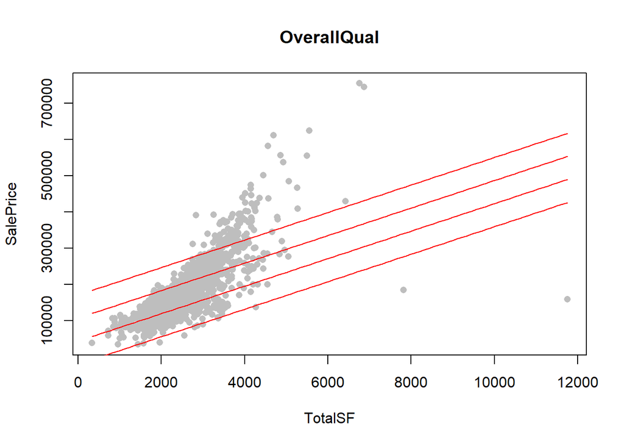

```r
options(scipen = 999)
plot(SalePrice ~ TotalSF, data = train, pch = 16, col = "grey", main = "OverallQual")

drawit1(col = "red", GarageArea = 500, YearBuilt = 2000, LotArea = 1000, YearRemodAdd = 2000, OverallQual = 1, TotalSF = 15000)

drawit1(col = "red", GarageArea = 500, YearBuilt = 2000, LotArea = 1000, YearRemodAdd = 2000, OverallQual = 4, TotalSF = 15000)

drawit1(col = "red", GarageArea = 500, YearBuilt = 2000, LotArea = 1000, YearRemodAdd = 2000, OverallQual = 7, TotalSF = 15000)

drawit1(col = "red", GarageArea = 500, YearBuilt = 2000, LotArea = 1000, YearRemodAdd = 2000, OverallQual = 10, TotalSF = 15000)
```

It is clear that OverallQual, combined with TotalSF, seems to be the most significant variable when it comes to SalePrice of the homes. Let’s drop the other terms and see how it holds up to parent data and the mytrain test data.

```r
model2 <- lm(SalePrice ~ TotalSF + OverallQual , data = train)
pander(summary(model2))
```

Table continues below

|  | Estimate | Std. Error | t value |
| --- | --- | --- | --- |
| **(Intercept)** | -102663 | 4787 | -21.44 |
| **TotalSF** | 44.32 | 1.729 | 25.63 |
| **OverallQual** | 27842 | 1027 | 27.1 |

|  | Pr(>\|t\|) |
| --- | --- |
| **(Intercept)** | 0.00000000000000000000000000000000000000000000000000000000000000000000000000000000000000006906 |
| **TotalSF** | 0.000000000000000000000000000000000000000000000000000000000000000000000000000000000000000000000000000000000000000000000006806 |
| **OverallQual** | 0.00000000000000000000000000000000000000000000000000000000000000000000000000000000000000000000000000000000000000000000000000000000002676 |

Fitting linear model: SalePrice ~ TotalSF + OverallQual

| Observations | Residual Std. Error | $R^2$ | Adjusted $R^2$ |
| --- | --- | --- | --- |
| 1460 | 40381 | 0.742 | 0.7416 |

```r
model3 <- lm(SalePrice ~ TotalSF + OverallQual , data = mytrain)
pander(summary(model3))
```

Table continues below

|  | Estimate | Std. Error | t value |
| --- | --- | --- | --- |
| **(Intercept)** | -107192 | 5464 | -19.62 |
| **TotalSF** | 50.11 | 2.088 | 23.99 |
| **OverallQual** | 26248 | 1202 | 21.84 |

|  | Pr(>\|t\|) |
| --- | --- |
| **(Intercept)** | 0.000000000000000000000000000000000000000000000000000000000000000000000001028 |
| **TotalSF** | 0.0000000000000000000000000000000000000000000000000000000000000000000000000000000000000000000000000000897 |
| **OverallQual** | 0.00000000000000000000000000000000000000000000000000000000000000000000000000000000000001079 |

Fitting linear model: SalePrice ~ TotalSF + OverallQual The adjusted R-squared of this model is *0.7723* for the my train and 0.7416 for the parent population data.

| Observations | Residual Std. Error | $R^2$ | Adjusted $R^2$ |
| --- | --- | --- | --- |
| 1000 | 38743 | 0.7728 | 0.7723 |